# Lesson 4

Timothy Luna

8/20/2019

# Linearity and Convolution

I would like to state, for the record, how aggravating the documentation is for the python wrapper around OpenCV.

## Intro

Linearity is important because of the operations we can do on images if the operations are linear!

An operator / system $H$ is called linear if two properties hold; $f_1$ and $f_2$ are functions and $a$ is a scalar constant.

1. Additivity: $H(f_1+f_2) = H(f_1) + H(f_2)$
2. Scalability (homegeneity of degree 1): $H(a \times f_1) = a \times H(f_1)$

Because of these properties the filter application is a linear process.

## Quiz: Linear

Max and roots are non-linear operators; sum and average are linear operators [^1].

## Impulse Function and Response

Linearity allows building an image one piece at a time and expresses how linear operators affect an image. Linearity says we can sum many components of an image to make a full image and that applying an operator to an image is the same as applying it to the pieces. *Linear separability* is the key word here.

The building block of functions is the impulse function; in the discrete world it is a single point with value 1. In the case of the (real) continuous world it is slightly trickier; calculus is required when considering an impulse in the continuous world as the length of time the impulse operates on dictates the magnitude of the function. The impulse function is *defined* as the function having an area of one over the time it operates; it is an integral from a to b equal to one.

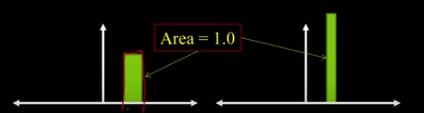

Impulse Function

A handy property of the impulse function is that if there is an unknown black box system (H) and nothing is known about it then system dynamics you can obtain the impulse response by applying an impulse.

If we know the impulse response h(x) of a black box H we can describe the effect of the operator by h(x).

Most importantly, if we can see the impulse response for a single point we know the effect of H on the whole image.

## Filtering an impulse signal

Given a single pixel with value of 1 filtered with some kernel / mask $H$, what is the output? What does it look like.

Using this small example where we have a simple and small image that we are operating on where all values are 0 save one element with a value of 1.

If we apply the filter in the row where the one is present we can see the effect of the filter; as we traverse across the image we see what the filter application looks like in the image itself.

The correlation filter of an impulse flips the response both left and right and up and down. It produces a mirror image of the original image with the filter applied.

This holds an implicit assumption that the center coordinate of the filter is the ‘reference point’.

## Quiz: Kernel

If the kernel was an $M\times M$ and the image was $N\times N$ how many multiples (individual operations) would it take to filter the whole image with the filter?

Although this requires some thought about how the border application is going to be handled (to be discussed in the future) an easy way to think about this is considering small cases. If we have a 3x3 image and a 1x1 filter it requires 9 applications where each application is one multiplication. If we have a 5x5 image and a 3x3 filter it requires 9 applications where each application is nine multiplications (if we exclude border regions).

As we continue to rise the number of multiplications is on the order of $m^2 n^2$; it grows exponentially both with the size of the image and the size of the filter because every pixel will be multiplied by every coefficient.

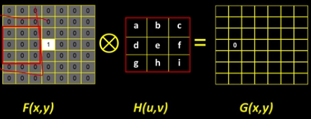

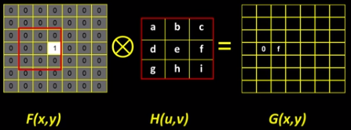

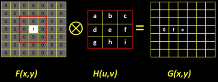

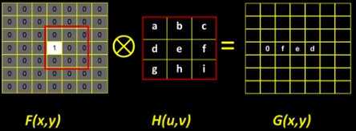

## Correlation vs Convolution

When put through a correlation filter the original image is reversed on both axes. Revisiting the equation for cross-correlation $G[i,j] = \sum_{u=-k}^k \sum_{v=-k}^k H[u,v] F[i + u, j+v]$ as we apply our kernel $H$ it flips the image.

When an impulse hits the filter the output is the reversed signal.

There is something called convolution $G[i,j] = \sum_{u=-k}^k \sum_{v=-k}^k H[u,v] F[i - u, j - v]$ and that means ‘apply the filter / kernel and flip the axes’. It performs nearly the same operations as the correlation filter but explicitly produces a results that is not flipped from the original image. (Note the subtraction in $F$.)

If using a gaussian or a box filter, what is the difference? Nothing! (Assuming a circularly symmetric kernel it doesn’t matter and there is no difference.)

If we’re taking derivatives it does matter and we will see this in some coming lessons, but otherwise it doesn’t matter!

The convention for showing the difference between a correlation and a convolution is to place the asterisk for a correlation in the upper right and for a convolution in the lower left: i.e.

- Correlation: $H^*$
- Convolution: $_*H$

This *only matters in an asymmetric filter*

## Quiz: Convolution

When convolving a filter with an impulse we get back the filter as the result, what do we get if we convolve an image with an impulse? The original image!

Think of the impulse as the identity function.

## Properties of Covolution

Convolutions are *shift invariant*. This property means that the operator behaves identically everywhere. Given some pixels in an arbitray location in the image and assuming that identical pixels are seen in another location the operator applied on both sets of pixels will produce identical results.

The value of the output depends on the pattern in the image neighborhood and *not* the position of the neighborhood.

Because of the linear properties of the convolution filtering is a linear operation and therefore some neat properties fall out.

- Convolution is commutative and thus $f$ convolved with $g$ is $g$ convolved with $f$: $f * g = g * f$,
- It’s also associative: $(f * g) * h = f * (g * h)$,
- Has an identity: A unit impulse $e=\begin{bmatrix} ... & 0 & 0 & 1 & 0 & 0 & ...\end{bmatrix} \rightarrow f * e=f$,
- And can therefore be differentiated: $\frac{\partial}{\partial x}(f * g) = \frac{\partial f}{\partial x} * g$.

## Computational Complexity and Seperability

If an image is sized $N \times N$ and a kernel is sized $W \times W$ how many multiplication operations are needed? As previously covered: on the order of $W^2 N^2$.

This can produce a *very large* number of operations but because of linearity there is a cute property that can minimize the number of operations.

At times your main filter can be created by convolving a single row with a single column; this is a linearly seperable kernel. $c * r = H$

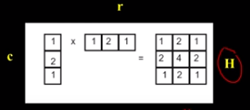

Linearly Seperable Kernel

If we want to filter something with $H$: $G=H * F = (c * r) * F = c * (r * F)$.

Using the associative property of the convolution and expressing the convolution as it’s component operations we can simply conduct the operations in a different order and therefore minimize the number of required operations. This conducts two convolutions each on the order of $2 W N^2$ operations which can be useful as $W$ grows large to the point that $2 W N^2 < < W^2 N^2$.

## Quiz: Linear Operation

Is division a linear operator? Yes! $\frac{x + y}{z} = \frac{x}{z} + \frac{y}{z}$. This is *linear seperability*.

## Boundary Issues

How are image boundaries handled when filtering images? It is completely undefined until you define it! What size of operation / output do you want?

- Full: The filter is outside the image all the way save one element at max.
- Same: The filter is outside the image just enough to return an output image that is the same size as the original image.
- Valid: The filter is never outside the image and returns an output image that is smaller than the original image.

## Methods

1. A clip flter: (assume outside boundary is monochrome) Introduces a monochromatic border.
2. Wrap around: (Fourier) Assume the picture continues at the border and wraps around. This assumes a periodic signal.
3. Copy edge / replicate: This extends the border and is easy with reasonable results.
4. Symmetric / reflection: Reflect the borders outward; this has the benefit of retaining the original images statistics.

OpenCV uses the following border types (image boundaries are denoted with ‘|’):

- BORDER_REPLICATE: aaaaaa|abcdefgh|hhhhhhh
- BORDER_REFLECT: fedcba|abcdefgh|hgfedcb
- BORDER_REFLECT_101: gfedcb|abcdefgh|gfedcba
- BORDER_WRAP: cdefgh|abcdefgh|abcdefg
- BORDER_CONSTANT: iiiiii|abcdefgh|iiiiiii with some specified ‘i’

## Quiz: Reflection Method

Reflection is good because the created image has the same statistics as the original image!

## Practicing With Linear Filters

Remember that an image convolved with an impulse returns same image.

But, what if the impulse is not centered? i.e. $\begin{bmatrix}0 & 0 & 0 \\ 0 & 0 & 1 \\ 0 & 0 & 0 \end{bmatrix}$? The image will shift! The shift depends on whether the filter is conducting correlation or convolution.

This is now a sharpening filter where the layer is ‘enhanced’ by scaling it and then the ‘average’ of all pixels near it is removed. This enhances the differences between nearby elements.

## Unsharp Mask

There is a history lesson here explaining that an ‘unsharp mask’ (which is a tool in things like Photoshop and sounds quite silly) came from taking a negative of a negative to sharpen the original image. This negative of the negative was called an ‘unsharp mask’.

## Quiz: Filter

A filter with non-normalized coefficients (i.e. that do not sum to one) can be corrected by multiplying by a scaling factor. Can the resulting image from applying the filter be corrected by multiplying by the square root of that scaling factor?

No. Remember that these filters are *linear* operators! That means that $G = aF * I$ is the same thing as $\frac{1}{a} G = F * I$. There’s no need for a square root operator, you multiply *by that scalar factor!*.

## Different Kinds of Noise

What different kinds of noise exist? Which filters are best for those types of noise?

Uniform random noise (read independent) is best filtered with Gaussian filters, but Salt and Pepper noise (random spots of negative maximum / minimum values) can be best fixed with a median filter. Remember that the median statistic is much less sensitive to high variance in a dataset than is the mean (as seen in the image to the right.)

## Median Filter

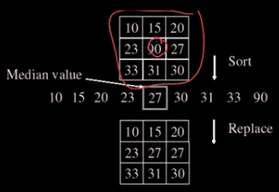

3X3 Median Filter

## Quiz: Apply a Median Filter

```python
# Read in the moon image
img = imread('moon.png')
imshow(img)

# Apply salt and pepper noise
def noise(img:np.ndarray,
          type:str="salt and pepper",
          noise:int=100):

  """
  This noise function takes as inputs an image to operate on and
  the type of noise to apply.
  img: An image file loaded in via OpenCV into Numpy arrays
  type: The type of noise in the set
    ["salt and pepper"]
  noise: An integer to be used in determining the noise density.
    Lower produces a noisier image.

  This returns a noisy image; note that this makes *no* assumptions
  about the structure of your original image! The image returned is
  the same size and dtype as the original image.
  """

  # What types are implemented?
  types = ["salt and pepper"]
  assert type in types, "You must select from {}".format(", ".join(types))

  # How much of the image will be modified?
  noisy = np.random.randint(pad,size=img.shape)

  if type == "salt and pepper":
    # What if salt and pepper is the method?
    # What are the maximum and minimum values in the image?
    salt = np.amin(img)
    pepper = np.amax(img)
    # Wherever noise is 0 create 'salt' noise
    img = np.where(noisy==0, salt, img)
    # Where noise is 'noise-1' create pepper noise
    img = np.where(noisy==noisy-1, pepper, img)
  return(img)

# Let's make it *really* noisy

img2 = noise(img,"salt and pepper",10)

# Note that this one-liner is a way to do it! This also shows different
#  levels of blurring

median = cv2.medianBlur(img2,3)
median = cv2.medianBlur(img2,5)
median = cv2.medianBlur(img2,7)
imshow(median)
```

[output not shown]

[^1]: http://mathworld.wolfram.com/LinearOperator.html